# Sensitivity Analysis Earth System configuration of JULES

Doug McNeall

21/09/2022

3. Crown copyright, Met Office

Sensitivity analysis for McNeall et al. (2022) “Constraining the carbon cycle in JULES-ES-1.0”

## 0.1 Preliminaries

Load libraries, functions and data.

```r
# Load helper functions

knitr::opts_chunk$set(fig.path = "figs/", echo = TRUE, message = FALSE, warnings = FALSE)

# load helper functions, data and do preliminary processing of the ensemble.
source("JULES-ES-1p0-common-packages.R")
source('JULES-ES-1p0-common-functions.R')
source('JULES-ES-1p0-common-data.R')

# locally specific packages
library(sensitivity)
```

```r
# Locally specific functions

# rotate a matric 90 degrees clockwise for plotting
rotate <- function(x) t(apply(x, 2, rev))

sensvar = function(oaat_pred, n, d){
  # Calculate variance as a global sensitivity meansure
  out = rep(NA,d)
  for(i in 1:d){
    ix = seq(from = ((i*n) - (n-1)), to =  (i*n), by = 1)
    out[i] = var(oaat_pred$mean[ix])
  }
  out
}


twoStep_sens <- function(X, y, n=21, predtype = 'UK', nugget=NULL, nuggetEstim=FALSE, noiseVar=NULL, seed=NULL, trace=FALSE, maxit=100,
                        REPORT=10, factr=1e7, pgtol=0.0, parinit=NULL, popsize=100){
  # Sensitivity analysis with twoStep emulator.
  # Calculates the variance of the output varied one at a time across each input.
  d = ncol(X)
  X_norm <- normalize(X)
  X_oaat <- oaat_design(X_norm, n, med = TRUE)
  colnames(X_oaat) = colnames(X)

  twoStep_em = twoStep_glmnet(X=X, y=y, nugget=nugget, nuggetEstim=nuggetEstim, noiseVar=noiseVar,
                              seed=seed, trace=trace, maxit=maxit,
                              REPORT=REPORT, factr=factr, pgtol=pgtol,
                              parinit=parinit, popsize=popsize)

  oaat_pred = predict(twoStep_em$emulator, newdata = X_oaat, type = predtype)

  sens = sensvar(oaat_pred = oaat_pred, n=n, d=d)
  out = sens
  out
}



oaatSensvarKm <- function(X, y, n = 21, med = TRUE, hold = NULL,  formula = ~., predtype = 'UK', ...){
  # one-at-a-time sensitivity summary with a standard dicekriging emulator

  d = ncol(X)
  X_norm <- normalize(X)
  X_oaat <- oaat_design(X_norm, n, med = med, hold = hold)
  colnames(X_oaat) = colnames(X)


  em <- km(formula = formula, design = X, response = y, ...)

  oaat_pred = predict(em, newdata = X_oaat, type = predtype)

  sens = sensvar(oaat_pred = oaat_pred, n=n, d=d)
  out = sens
  out

}

oaatSensvarKmList <- function(X, em_list, n = 21, med = TRUE, hold = NULL,  formula = ~., predtype = 'UK', ...){
  # one-at-a-time sensitivity summary with a standard dicekriging emulator

  d = ncol(X)
  X_oaat <- oaat_design(X, n, med = med, hold = hold)
  colnames(X_oaat) = colnames(X)

  em <- em_list[[i]]

  oaat_pred = predict(em, newdata = X_oaat, type = predtype)

  sens = sensvar(oaat_pred = oaat_pred, n=n, d=d)
  out = sens
  out

}


oaatSensvarSummaryPlot <- function(oat_sens_mat){

  # relies on rotate(), fields

  ynames <- rownames(oat_sens_mat)
  xnames <- colnames(oat_sens_mat)

  normsens <- normalize(t(oat_sens_mat))
  normsens_mean <- apply(normsens,1, mean)

  sort_ix <- sort(normsens_mean, decreasing = TRUE, index.return = TRUE)

  par(mar = c(15,12,5,1), mfrow = c(1,2))

  layout(matrix(c(1,1,2), ncol = 3, nrow = 1))

  image(rotate(normsens[sort_ix$ix, ]), axes = FALSE, col = blues)

  axis(1, at = seq(from = 0, to = 1, length.out = length(ynames)), labels = ynames, las = 3, cex.axis = 1.2)
  axis(2, at = seq(from = 1, to = 0, length.out = length(xnames)), labels = xnames[sort_ix$ix], las = 1, cex.axis = 1.2)
  mtext('One-at-a-time sensitivity', side = 3, adj = 0, line = 2, cex = 1)

  lab_ix <- (1:length(xnames)) - 0.5

  par(yaxs = 'i', mar = c(15,1,5,5))
  plot(rev(normsens_mean[sort_ix$ix]), lab_ix, xlab = 'mean oaat variance (normalized)', ylab = '', ylim = c(0,length(xnames)), type = 'n', yaxt = 'n')
  abline(h = lab_ix, col = 'grey', lty = 'dashed')
  points( rev(normsens_mean[sort_ix$ix]),lab_ix, col = zissou5[1], pch = 19, cex = 1.5)

  image.plot(legend.only = TRUE,
             zlim = c(0,1),
             col = blues,
             legend.args = list(text = 'Relative sensitivity', side = 3, line = 1),
             horizontal = TRUE
  )

}



sensMatSummaryPlot <- function(sens_mat, col = blues, maintext = 'Sensitivity Matrix', xlab = 'sensitivity summary'){
  # Summary plots of a sensitivity matrix
  # relies on rotate(), fields

  ynames <- rownames(sens_mat)
  xnames <- colnames(sens_mat)

  normsens <- normalize(t(sens_mat))
  normsens_mean <- apply(normsens,1, mean)

  sort_ix <- sort(normsens_mean, decreasing = TRUE, index.return = TRUE)

  par(mar = c(15,12,5,1), mfrow = c(1,2))

  layout(matrix(c(1,1,2), ncol = 3, nrow = 1))

  image(rotate(normsens[sort_ix$ix, ]), axes = FALSE, col = col)

  axis(1, at = seq(from = 0, to = 1, length.out = length(ynames)), labels = ynames, las = 3, cex.axis = 1.2)
  axis(2, at = seq(from = 1, to = 0, length.out = length(xnames)), labels = xnames[sort_ix$ix], las = 1, cex.axis = 1.2)
  mtext(maintext, side = 3, adj = 0, line = 2, cex = 1)

  lab_ix <- (1:length(xnames)) - 0.5

  par(yaxs = 'i', mar = c(15,1,5,5))
  plot(rev(normsens_mean[sort_ix$ix]), lab_ix, xlab = xlab, ylab = '', ylim = c(0,length(xnames)), type = 'n', yaxt = 'n')
  abline(h = lab_ix, col = 'grey', lty = 'dashed')
  points( rev(normsens_mean[sort_ix$ix]),lab_ix, col = zissou5[1], pch = 19, cex = 1.5)

  image.plot(legend.only = TRUE,
             zlim = c(0,1),
             col = col,
             legend.args = list(text = 'Relative sensitivity', side = 3, line = 1),
             horizontal = TRUE
  )
}


bp_convert <- function(fastmodel){
  # get the FAST summary into an easier format for barplot
  fast_summ <- print(fastmodel)
  fast_diff <- fast_summ[ ,2] - fast_summ[ ,1]
  fast_bp <- t(cbind(fast_summ[ ,1], fast_diff))
  fast_bp
}


multiFAST<- function(X, Y, fit_list = NULL, n = 1000){
  # FAST analysis for multiple outputs

  # Generate a design for the FAST99 analysis
  X_fast <- fast99(model = NULL, factors = colnames(X), n = n,
                   q = "qunif", q.arg = list(min = 0, max = 1))

  if(is.null(fit_list)){
    fit_list <- createKmFitList(X = X, Y = Y)
  }

  else{
  fit_list <- fit_list
  }

  fast_tell_list <- vector(mode = 'list', length = ncol(Y))

  for(i in 1:ncol(Y)){

    fit <- fit_list[[i]]
    # Predict the response at the FAST99 design points using the emulator
    pred_fast <- predict(fit, newdata = X_fast$X, type = 'UK')

    # Calculate the sensitivity indices
    fast_tell <- tell(X_fast, pred_fast$mean)

    fast_tell_list[[i]] <- fast_tell

  }

  return(list(fit_list = fit_list, fast_tell_list = fast_tell_list))

}

oaatSensvarRank <- function(oat_sens_mat){

  ynames <- rownames(oat_sens_mat)
  xnames <- colnames(oat_sens_mat)

  normsens <- normalize(t(oat_sens_mat))
  normsens_mean <- apply(normsens,1, mean)

  rank <- rank(-normsens_mean)

  return(list(mean = normsens_mean, rank = rank))

}

SensRank <- function(sens_mat){

  # summarising and ranking parameters in a sensitivity matrix

  ynames <- rownames(sens_mat)
  xnames <- colnames(sens_mat)

  normsens <- normalize(t(sens_mat))
  normsens_mean <- apply(normsens,1, mean)

  rank <- rank(-normsens_mean)

  return(list(mean = normsens_mean, rank = rank))

}
```

to find the “standard” value in normalized space, we can normalize a vector of “1s” with respect to the original design

```r
X_standard <- matrix(rep(1,d), ncol = d, nrow = 1)

X_standard_norm <- normalize(X_standard, wrt = lhs)

lhs_min <- apply(lhs_wave0_wave01_all, 2, min)
lhs_max <- apply(lhs_wave0_wave01_all,2, max)

X_level1a_unnorm <- unnormalize(X_level1a, un_mins = lhs_min, un_maxes = lhs_max)

X_level1a_wave01_unnorm <- unnormalize(X_level1a_wave01, un_mins = lhs_min, un_maxes = lhs_max)
```

# 1 Sensitivity at level1a constraint (f0_io and b_wl_io truncated)

Define constraint level 1a as those members that run, and have F0_io <0.9 & b_wl_io > 0.15 (normalised).

## 1.1 Modern value sensitivity

```r
oaat_level1a_Y_file <- 'data/oaat_level1a_Y.rdata'

if (file.exists(oaat_level1a_Y_file)) {
  load(oaat_level1a_Y_file)
} else {

oat_var_sensmat_level1a_Y <- matrix(NA, nrow = length(y_names_sum), ncol = ncol(X_level1a))

for(i in 1:length(y_names_sum)){

  yname <- y_names_sum[i]
  y <- Y_level1a[, yname]
  oat <- oaatSensvarKmList(X = X_level1a, em_list = emlist_km_Y_level1a, med = FALSE, hold = X_standard_norm)
  oat_var_sensmat_level1a_Y[i, ] <- oat
}

save(y_names_sum, oat_var_sensmat_level1a_Y, file = oaat_level1a_Y_file)
}

rownames(oat_var_sensmat_level1a_Y) <- y_names_sum
colnames(oat_var_sensmat_level1a_Y) <- colnames(X_level1a)

#normsens_level1a_Y <- normalize(t(oat_var_sensmat_level1a_Y))
```

```r
pdf(file = 'figs/oat_var_sensmat_level1a_Y.pdf', width = 7, height = 8)
oaatSensvarSummaryPlot(oat_var_sensmat_level1a_Y)

dev.off()
```

## 1.2 Anomaly (Change 1850 - 2013) sensitivities

```r
oaat_level1a_YAnom_file <- 'data/oaat_level1a_YAnom.rdata'

if (file.exists(oaat_level1a_YAnom_file)) {
  load(oaat_level1a_YAnom_file)
} else {

oat_var_sensmat_level1a_YAnom <- matrix(NA, nrow = length(y_names_sum), ncol = ncol(X_level1a))

for(i in 1:length(y_names_sum)){

  yname <- y_names_sum[i]
  y <- YAnom_level1a[, yname]
  oat <- oaatSensvarKmList(X = X_level1a, em_list = emlist_km_YAnom_level1a,  med = FALSE, hold = X_standard_norm)
  oat_var_sensmat_level1a_YAnom[i, ] <- oat
}

save(y_names_sum, oat_var_sensmat_level1a_YAnom, file = oaat_level1a_YAnom_file)
}


rownames(oat_var_sensmat_level1a_YAnom) <- y_names_sum
colnames(oat_var_sensmat_level1a_YAnom) <- colnames(X_level1a)

# Normalise sensitivities
#normsens_level1a_YAnom <- normalize(t(oat_var_sensmat_level1a_YAnom))
```

```r
pdf(file = 'figs/oat_var_sensmat_level1a_YAnom.pdf', width = 7, height = 8)
oaatSensvarSummaryPlot(oat_var_sensmat_level1a_YAnom)
dev.off()
```

## 1.3 One-at-a-time sensitivity analysis of constraining variables for understanding model response

“Constraining variables” being those we use to constrain the model (npp, nbp, cSoil and cVeg). It’s hard to maintain a high vegetation carbon in particular.

Further idea: What parameter values might you choose to do this, and what might be the trade-offs you have to make?

```r
Y_const_level1a_scaled_list <- mat2list(Y_const_level1a_scaled)
fit_list_const_level1a <- mclapply(X = Y_const_level1a_scaled_list, FUN = km, formula = ~., design = X_level1a,
                                   mc.cores = 4, control = list(trace = FALSE))
```

```r
# Check that oatSensVar and the plotting make sense

oaat_sens_cVeg <- oaatSensvarKm(X = X_level1a, y = Y_const_level1a_scaled[,"cVeg_lnd_sum"])
```

[output not shown]

[output cut: 45 more lines]

[output not shown]

```r
X_oaat_level1a <- oaat_design(X_level1a, n=21, med = FALSE, hold = X_standard_norm)

colnames(X_oaat_level1a) = colnames(X)

y_oaat <- predict.km(fit_list_const_level1a[[4]], newdata = X_oaat_level1a, type = 'UK')
```

First, what parameters affect vegetation carbon and how? How sure are we about that?

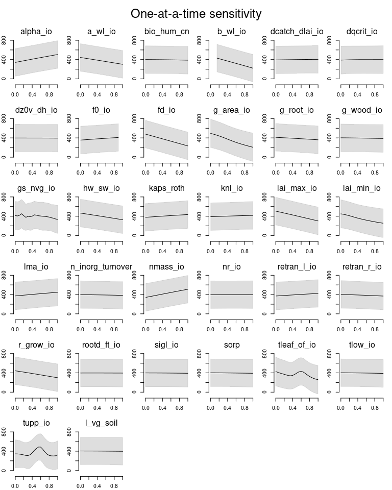

```r
oaatLinePlot(X_oaat = X_oaat_level1a, y_oaat_mean = y_oaat$mean, y_oaat_sd = y_oaat$sd,
             n_oaat = 21,nr = 6, nc = 6)
```

```r
NA
NA
```

```r
Y_oaat_const_level1a_scaled <- matrix(ncol = ncol(Y_const_level1a_scaled), nrow = nrow(X_oaat_level1a))

for(i in 1:ncol(Y_const_level1a_scaled)){

  y_oaat <- predict.km(fit_list_const_level1a[[i]], newdata = X_oaat_level1a, type = 'UK')
  Y_oaat_const_level1a_scaled[,i] <- y_oaat$mean
}
```

What might be the trade-offs for a high (or accurate) vegetation carbon? are they acceptable? Plot the oaat sensitivity of the other 3 outputs we’re calibrating on.

Plotting these graphs in the original input space (multiplication factors) and providing the standard has the pleasing side effect of showing what you could do to standard inputs to increase or decrease a particular output.

```r
Y_oaat_const_level1a_scaled_norm <- normalize(Y_oaat_const_level1a_scaled)

        oaatLinePlotMulti <- function(X_oaat, Y_oaat, n_oaat, nr, nc, cols, ...){

          par(mfrow = c(nr,nc), oma = c(0.1,0.1,3,0.1), mar = c(2,2,3,1), las = 1)

          for(i in 1:ncol(X_oaat)){
            ix <- seq(from = ((i*n_oaat) - (n_oaat-1)), to =  (i*n_oaat), by = 1)

            plot(X_oaat[ix,i], Y_oaat[ix,1],
                 ylim = c(0,1),
                 xlab = colnames(X_oaat)[i],
                 type= 'n',
                 bty = 'n')

            for(j in 1:ncol(Y_oaat)){
              lines(X_oaat[ix,i], Y_oaat[ix, j], lty = 'solid', col = cols[j], ...)
              abline(v = 1, lty = 'dashed', col = 'grey')
              mtext(colnames(X_oaat)[i], side = 3, line = 0.5)

            }

          }

        }

X_oaat_level1a_unnorm <- unnormalize(X_oaat_level1a, un_mins = lhs_min, un_maxes = lhs_max)
pdf(file = 'figs/Y_oaat_const_level1a_scaled_norm.pdf', width = 10, height = 10)
oaatLinePlotMulti(X_oaat = X_oaat_level1a_unnorm, Y_oaat = Y_oaat_const_level1a_scaled_norm ,  n_oaat = 21, nr = 6, nc = 6,
                  lwd = 3, col = cbPal[c(1,2,6,8)])

reset()
legend('top', c('nbp', 'npp', 'csoil', 'cveg'), col = cbPal[c(1,2,6,8)], lty = 'solid', lwd = 3, horiz = TRUE)
dev.off()
```

## 1.4 Update for wave01

```r
# Build list of emulators for both waves, standard constraint parameters.

Y_const_level1a_wave01_scaled_list <- mat2list(Y_const_level1a_wave01_scaled)
fit_list_const_level1a_wave01 <- mclapply(X = Y_const_level1a_wave01_scaled_list, FUN = km, formula = ~., design = X_level1a_wave01,
                                   mc.cores = 4, control = list(trace = FALSE))
```

```r
Y_oaat_const_level1a_wave01_scaled <- matrix(ncol = ncol(Y_const_level1a_wave01_scaled), nrow = nrow(X_oaat_level1a))

for(i in 1:ncol(Y_oaat_const_level1a_wave01_scaled)){

  y_oaat <- predict.km(fit_list_const_level1a_wave01[[i]], newdata = X_oaat_level1a, type = 'UK')
  Y_oaat_const_level1a_wave01_scaled[,i] <- y_oaat$mean
}
```

```r
Y_oaat_const_level1a_wave01_scaled_norm <- normalize(Y_oaat_const_level1a_wave01_scaled)

pdf(file = 'figs/fig09.pdf', width = 10, height = 10)
#pdf(file = 'figs/Y_oaat_const_level1a_wave01_scaled_norm.pdf', width = 10, height = 10)
oaatLinePlotMulti(X_oaat = X_oaat_level1a_unnorm, Y_oaat = Y_oaat_const_level1a_wave01_scaled_norm ,  n_oaat = 21, nr = 6, nc = 6,
                  lwd = 3, col = cbPal[c(1,2,6,8)])

reset()
legend('top', c('nbp', 'npp', 'csoil', 'cveg'), col = cbPal[c(1,2,6,8)], lty = 'solid', lwd = 3, horiz = TRUE)
dev.off()
```

```r
Y_sum_level1a_wave01_list <- mat2list(Y_sum_level1a_wave01)

emlist_km_Y_level1a_wave01_file <- "data/emlist_km_Y_level1a_wave01_2022-09-21.rdata"

if (file.exists(emlist_km_Y_level1a_wave01_file)) {
  load(emlist_km_Y_level1a_wave01_file)
} else {

  # Here, the list is a list version of the matrix Y_
  emlist_km_Y_level1a_wave01 <- mclapply(X = Y_sum_level1a_wave01_list, FUN = km, formula = ~., design = X_level1a_wave01, mc.cores = 4)

  save( emlist_km_Y_level1a_wave01, file = emlist_km_Y_level1a_wave01_file)

}
```

```r
oaat_level1a_wave01_Y_file <- 'data/oaat_level1a_wave01_Y.rdata'

if (file.exists(oaat_level1a_wave01_Y_file)) {
  load(oaat_level1a_wave01_Y_file)
} else {

oat_var_sensmat_level1a_wave01_Y <- matrix(NA, nrow = length(y_names_sum), ncol = ncol(X_level1a))

for(i in 1:length(y_names_sum)){

  yname <- y_names_sum[i]
  y <- Y_level1a[, yname]
  oat <- oaatSensvarKmList(X = X_level1a_wave01, em_list = emlist_km_Y_level1a_wave01, med = FALSE, hold = X_standard_norm)
  oat_var_sensmat_level1a_wave01_Y[i, ] <- oat
}

save(y_names_sum, oat_var_sensmat_level1a_wave01_Y, file = oaat_level1a_wave01_Y_file)
}

rownames(oat_var_sensmat_level1a_wave01_Y) <- y_names_sum
colnames(oat_var_sensmat_level1a_wave01_Y) <- colnames(X_level1a)

#normsens_level1a_Y <- normalize(t(oat_var_sensmat_level1a_Y))
```

```r
pdf(file = 'figs/fig07.pdf', width = 7, height = 8)
#pdf(file = 'figs/oat_var_sensmat_level1a_wave01_Y.pdf', width = 7, height = 8)
oaatSensvarSummaryPlot(oat_var_sensmat_level1a_wave01_Y)

dev.off()
```

## 1.5 Anomaly wave01

```r
YAnom_sum_level1a_wave01_list <- mat2list(YAnom_sum_level1a_wave01)

emlist_km_Y_level1a_wave01_file <- 'data/emlist_km_Y_level1a_wave01_file_2022-09-21.rdata'

if (file.exists(emlist_km_Y_level1a_wave01_file)) {
  load(emlist_km_Y_level1a_wave01_file)
} else {

  # Here, the list is a list version of the matrix Y_
  emlist_km_YAnom_level1a_wave01 <- mclapply(X = YAnom_sum_level1a_wave01_list, FUN = km, formula = ~., design = X_level1a_wave01, mc.cores = 4)

  save( emlist_km_YAnom_level1a_wave01, file = emlist_km_Y_level1a_wave01_file)

}
```

```r
oat_var_sensmat_level1a_wave01_YAnom <- matrix(NA, nrow = length(y_names_sum), ncol = ncol(X_level1a))

for(i in 1:length(y_names_sum)){

  yname <- y_names_sum[i]
  y <- Y_level1a[, yname]
  oat <- oaatSensvarKmList(X = X_level1a_wave01, em_list = emlist_km_YAnom_level1a_wave01, med = FALSE, hold = X_standard_norm)
  oat_var_sensmat_level1a_wave01_YAnom[i, ] <- oat
}

#save(y_names_sum, oat_var_sensmat_level1a_Y, file = "oaat_level1a_Y.rdata")
#}

rownames(oat_var_sensmat_level1a_wave01_YAnom) <- y_names_sum
colnames(oat_var_sensmat_level1a_wave01_YAnom) <- colnames(X_level1a)

#normsens_level1a_Y <- normalize(t(oat_var_sensmat_level1a_Y))
```

```r
pdf(file = 'figs/fig08.pdf', width = 7, height = 8)
#pdf(file = 'figs/oat_var_sensmat_level1a_wave01_YAnom.pdf', width = 7, height = 8)
oaatSensvarSummaryPlot(oat_var_sensmat_level1a_wave01_YAnom)

dev.off()
```

# 2 FAST sensitivity analysis

```r
# Need to think about how mins and maxes are dealt with - we have a truncated input design

# Generate a design for the FAST99 analysis
X_fast <- fast99(model = NULL, factors = colnames(X_level1a_wave01), n = 3000,
                 q = "qunif", q.arg = list(min = 0, max = 1))
```

Create a list of sensitivity analyses, one for each column of the “sum” (modern) output matrix. (This now uses wave01 data)

```r
MF_Y_sum_level1a_file <- 'data/MF_Y_sum_level1a.rdata'

if(file.exists(MF_Y_sum_level1a_file )){

  load(MF_Y_sum_level1a_file )
} else
{

MF_Y_sum_level1a <- multiFAST(X = X_level1a_wave01, Y = Y_sum_level1a_wave01, fit_list = emlist_km_Y_level1a_wave01, n = 1000)

save(MF_Y_sum_level1a, file = MF_Y_sum_level1a_file )
}
```

Create a sensitivity summary matrix from the list of sensitivity analyses.

```r
FAST_total_Y_sum_level1a <- matrix(nrow = length(MF_Y_sum_level1a$fast_tell_list), ncol = d)

for(i in 1:length(MF_Y_sum_level1a$fast_tell_list)){

  # sum the direct effect and interaction terms to get a total
  FAST_total_Y_sum_level1a[i, ] <- apply(bp_convert(MF_Y_sum_level1a$fast_tell_list[[i]]),2,sum)
}
colnames(FAST_total_Y_sum_level1a) <- colnames(X_level1a)
rownames(FAST_total_Y_sum_level1a) <- colnames(Y_sum_level1a)
```

Plot the summary matrix

```r
pdf(file = 'figs/figA05.pdf', width = 7, height = 8)
#pdf(file = 'figs/FAST_sensmat_Y_level1a_wave01.pdf', width = 7, height = 8)
sensMatSummaryPlot(FAST_total_Y_sum_level1a)
dev.off()
```

Now create a list of sensitivity analyses for the anomaly at the end of the run.

```r
MF_YAnom_sum_level1a_file <- 'data/MF_YAnom_sum_level1a.rdata'

if(file.exists(MF_YAnom_sum_level1a_file )){

  load(MF_YAnom_sum_level1a_file )
} else
{

#MF_Y_sum_level1a <- multiFAST(X = X_level1a_wave01, Y = Y_sum_level1a_wave01, fit_list = emlist_km_Y_level1a_wave01, n = 1000)
MF_YAnom_sum_level1a <- multiFAST(X = X_level1a_wave01, Y = YAnom_sum_level1a_wave01, fit_list = emlist_km_YAnom_level1a_wave01, n = 1000)

save(MF_YAnom_sum_level1a, file = MF_YAnom_sum_level1a_file )
}
```

```r
pdf(file = 'figs/figA06.pdf', width = 7, height = 8)
sensMatSummaryPlot(FAST_total_YAnom_sum_level1a)
dev.off()
```

# 3 Monte Carlo Filtering

```r
# ---------------------------------------------------------------------------------
# Monte carlo filtering for sensitivity analysis
# ---------------------------------------------------------------------------------

# Uniform sample from across parameter space
# Split the sample into 'behavioural' (NROY) and 'Non behavioural (Ruled Out)
# Build cdfs of the marginal distributions in each case
# Perform a KS test to see if the smaples are drawn from different distributions
# The KS statistic is an indicator of the importance of the parameter in splitting the
# samples.

# "Not in" function
'%!in%' <- function(x,y)!('%in%'(x,y))

mcf = function(X, nroy_ix){

  ## Monte Carlo Filtering function
  ## X   ............... Complete sample from input space
  ## nroy.ix ........... index of cases of X which are NROY (Not Ruled Out Yet), or 'behavioural'.

  ## produces ks statistic for each column of the input matrix X
  ## A larger ks statistic means that input is more important for
  ## determining if a sample is NROY or not

  X_nroy = X[nroy_ix, ]

  ref = 1:nrow(X)
  ro_ix = which(ref %!in% nroy_ix)
  X_ro = X[ro_ix, ]

  kss = rep(NA, length = ncol(X))
  for(i in 1:ncol(X)){

    ks = ks.test(X_ro[,i], X_nroy[,i])
    kss[i] = ks$statistic

  }

  out = kss
  out
}
```

This repeats some code from the constraint analysis in order to do MCF using the observations (constraints) we have.

```r
# nbp  npp  csoil  cveg
Y_lower <- c(-10, 35, 750, 300)
Y_upper <- c(10, 80, 3000, 800)

# I'm going to set it so that + 4sd aligns approximately with the original limits
# given by Andy Wiltshire. This gives room for uncertainty from the emulator
Y_target = Y_upper - (abs(Y_upper - (Y_lower)) / 2 )# abs() to fix the problem with negative numbers


# standard deviation is derived from the limits and the central target
# (this distance is assumed to be 4 standard deviations.
Y_sd = (Y_upper - Y_target) / 4
names(Y_sd) = colnames(Y_const_level1a_wave01_scaled)


p = ncol(Y_const_level1a_wave01_scaled)

obs_sd_list = as.list(rep(0.01,p))
disc_list =  as.list(rep(0,p))
disc_sd_list =  as.list(Y_sd)
thres = 3

mins_aug = apply(X_level1a, 2, FUN = min)
maxes_aug =apply(X_level1a, 2, FUN = max)

# convert Y_target for ingestion into function
Y_target = matrix(Y_target, nrow = 1)
```

```r
# First build an emulator list for the Y

emlist_Y_const_level1a_wave01_scaled <- mclapply(X = Y_const_level1a_wave01_scaled_list, FUN = km, formula = ~.,
                                                 design = X_level1a_wave01, mc.cores = 4,
                                          control = list(trace = FALSE))
```

```r
# Samples from a uniform distribution across all of input space
nsamp_unif <- 10000
X_unif <- samp_unif(nsamp_unif, mins = (rep(0, d)), maxes = rep(1,d))

Y_unif <- matrix(nrow = nsamp_unif, ncol = ncol(Y_const_level1a_wave01_scaled))
colnames(Y_unif) <- colnames(Y_const_level1a_wave01_scaled)

# Build an emulator for each output individually
for(i in 1:ncol(Y_const_level1a_wave01_scaled)){
  em <- emlist_Y_const_level1a_wave01_scaled[[i]]
  pred <- predict(em, newdata = X_unif, type = 'UK')
  Y_unif[,i] <- pred$mean
}
```

```
newdata not named: newdata's variables are inherited from the designnewdata not named: newdata's variables are inherited from the designnewdata not named: newdata's variables are inherited from the designnewdata not named: newdata's variables are inherited from the design
```

```r
# This uses MCF with the constraints set by AW, rather than with a formal history match.

mcf_nbp = mcf(X_unif, which(Y_unif[,'nbp_lnd_sum'] > 0))
mcf_npp = mcf(X_unif, which(Y_unif[,'npp_nlim_lnd_sum'] > 35 & Y_unif[,'npp_nlim_lnd_sum'] < 80))
mcf_cSoil = mcf(X_unif, which(Y_unif[,'cSoil_lnd_sum'] > 750 & Y_unif[,'cSoil_lnd_sum'] < 3000))
mcf_cVeg <- mcf(X_unif, which(Y_unif[,'cVeg_lnd_sum'] > 300 & Y_unif[,'cVeg_lnd_sum'] < 800))

mcf_all_const <- mcf(X_unif, which(Y_unif[,'cVeg_lnd_sum'] > 300 & Y_unif[,'cVeg_lnd_sum'] < 800 & Y_unif[,'cSoil_lnd_sum'] > 750 & Y_unif[,'cSoil_lnd_sum'] < 3000 & Y_unif[,'npp_nlim_lnd_sum'] > 35 & Y_unif[,'npp_nlim_lnd_sum'] < 80 & Y_unif[,'nbp_lnd_sum'] > 0))

mcf_summary <- matrix(rbind(mcf_nbp, mcf_npp, mcf_cSoil, mcf_cVeg, mcf_all_const), nrow = ncol(Y_const_level1a_wave01_scaled)+1)
colnames(mcf_summary) <- colnames(X_level1a)
rownames(mcf_summary) <- c('nbp', 'npp', 'cSoil', 'cVeg', 'all')
```

```r
pdf(file = 'figs/fig10.pdf', width = 6, height = 8 )
#pdf(file = 'figs/MCF_sensmat_Yconst_level1a_wave01.pdf', width = 6, height = 8 )
sensMatSummaryPlot(mcf_summary)
dev.off()
```

```r
# using all together is quite similar to using the mean
plot(1:32, mcf_all_const, ylim = c(0,0.7), pch = 19)
points(1:32, mcf_npp, col = 'red', pch = 19)
```

```r
points(1:32, mcf_cVeg, col = 'green', pch = 19)
points(1:32, mcf_cSoil, col = 'brown', pch = 19)
```

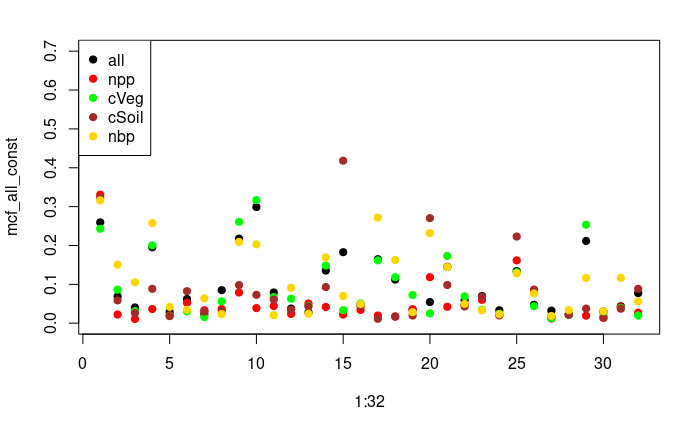

```r
points(1:32, mcf_nbp, col = 'gold', pch = 19)

legend('topleft', legend = c('all', 'npp', 'cVeg', 'cSoil', 'nbp'),
       col = c('black','red','green', 'brown', 'gold' ),
       pch = 19)
```

```r
NA
NA
```

```r
sensrank_Y_level1a_mcf <- SensRank(mcf_summary[1:4, ])
```

### 3.0.1 Ranking sensitivity of the parameters.

The idea here is to summarise the relative importance of the input parameters. The sensitivity measures are normalised

```r
sensrank_Y_level1a_oat <- SensRank(oat_var_sensmat_level1a_wave01_Y)
sensrank_YAnom_level1a_oat <- SensRank(oat_var_sensmat_level1a_wave01_YAnom)

sensrank_FAST <- SensRank(FAST_total_Y_sum_level1a)
sensrank_FAST_YAnom <- SensRank(FAST_total_YAnom_sum_level1a)


sens_ranks <- cbind(sensrank_Y_level1a_oat$rank,sensrank_FAST$rank,  sensrank_YAnom_level1a_oat$rank, sensrank_FAST_YAnom$rank, sensrank_Y_level1a_mcf$rank)
colnames(sens_ranks) <- c('OAT_modern_value', 'FAST_modern_value', 'OAT_anomaly', 'FAST_anomaly', 'MCF_modern_value')

min_rank <- apply(sens_ranks,1, min)

all_ranks <- cbind(sens_ranks, min_rank)

#plot(sens_ranks[,1], sens_ranks[,2], xlab = 'modern value rank', ylab = 'anomaly rank')


rank_ix <- sort(min_rank, decreasing = FALSE, index.return = TRUE)

# All ranks is the table of rankings, with min_rank being the highest ranking
sens_table <- all_ranks[rank_ix$ix, ]
```

```r
sens_table
```

```
                 OAT_modern_value FAST_modern_value OAT_anomaly FAST_anomaly MCF_modern_value min_rank
alpha_io                        1                 1           2            2                1        1
lai_max_io                      4                 6           1            1                7        1
b_wl_io                         2                 2           5            3                6        2
fd_io                           5                 4           3            4                2        2
g_area_io                       3                 5           4            5                3        3
n_inorg_turnover                8                 3           8            6                5        3
r_grow_io                       9                 8          12            8                4        4
lma_io                          6                 7           9           15               25        6
tleaf_of_io                     7                11           6           11               11        6
a_wl_io                        10                 9           7            7               13        7
kaps_roth                      14                13          20           14                8        8
nmass_io                       11                10          13            9                9        9
bio_hum_cn                     29                25          14           10               22       10
hw_sw_io                       17                15          18           16               10       10
lai_min_io                     15                14          10           13               12       10
tupp_io                        16                17          11           12               15       11
dqcrit_io                      12                12          17           17               18       12
rootd_ft_io                    13                16          16           19               14       13
g_wood_io                      22                22          15           20               16       15
nr_io                          20                21          23           22               17       17
f0_io                          19                18          19           18               26       18
g_root_io                      18                19          22           24               20       18
retran_l_io                    26                20          24           23               19       19
dz0v_dh_io                     21                24          21           21               27       21
l_vg_soil                      25                27          25           27               21       21
gs_nvg_io                      23                23          28           25               24       23
knl_io                         27                26          31           28               23       23
sorp                           24                30          27           31               29       24
dcatch_dlai_io                 28                29          29           26               28       26
retran_r_io                    30                28          26           29               30       26
sigl_io                        32                32          32           30               32       30
tlow_io                        31                31          30           32               31       30
```

```r
library(xtable)
xtable(sens_table, digits = 0)
```

```
% latex table generated in R 3.6.3 by xtable 1.8-4 package
% Wed Oct  5 18:45:06 2022
\begin{table}[ht]
\centering
\begin{tabular}{rrrrrrr}
  \hline
 & OAT\_modern\_value & FAST\_modern\_value & OAT\_anomaly & FAST\_anomaly & MCF\_modern\_value & min\_rank \\
  \hline
alpha\_io & 1 & 1 & 2 & 2 & 1 & 1 \\
  lai\_max\_io & 4 & 6 & 1 & 1 & 7 & 1 \\
  b\_wl\_io & 2 & 2 & 5 & 3 & 6 & 2 \\
  fd\_io & 5 & 4 & 3 & 4 & 2 & 2 \\
  g\_area\_io & 3 & 5 & 4 & 5 & 3 & 3 \\
  n\_inorg\_turnover & 8 & 3 & 8 & 6 & 5 & 3 \\
  r\_grow\_io & 9 & 8 & 12 & 8 & 4 & 4 \\
  lma\_io & 6 & 7 & 9 & 15 & 25 & 6 \\
  tleaf\_of\_io & 7 & 11 & 6 & 11 & 11 & 6 \\
  a\_wl\_io & 10 & 9 & 7 & 7 & 13 & 7 \\
  kaps\_roth & 14 & 13 & 20 & 14 & 8 & 8 \\
  nmass\_io & 11 & 10 & 13 & 9 & 9 & 9 \\
  bio\_hum\_cn & 29 & 25 & 14 & 10 & 22 & 10 \\
  hw\_sw\_io & 17 & 15 & 18 & 16 & 10 & 10 \\
  lai\_min\_io & 15 & 14 & 10 & 13 & 12 & 10 \\
  tupp\_io & 16 & 17 & 11 & 12 & 15 & 11 \\
  dqcrit\_io & 12 & 12 & 17 & 17 & 18 & 12 \\
  rootd\_ft\_io & 13 & 16 & 16 & 19 & 14 & 13 \\
  g\_wood\_io & 22 & 22 & 15 & 20 & 16 & 15 \\
  nr\_io & 20 & 21 & 23 & 22 & 17 & 17 \\
  f0\_io & 19 & 18 & 19 & 18 & 26 & 18 \\
  g\_root\_io & 18 & 19 & 22 & 24 & 20 & 18 \\
  retran\_l\_io & 26 & 20 & 24 & 23 & 19 & 19 \\
  dz0v\_dh\_io & 21 & 24 & 21 & 21 & 27 & 21 \\
  l\_vg\_soil & 25 & 27 & 25 & 27 & 21 & 21 \\
  gs\_nvg\_io & 23 & 23 & 28 & 25 & 24 & 23 \\
  knl\_io & 27 & 26 & 31 & 28 & 23 & 23 \\
  sorp & 24 & 30 & 27 & 31 & 29 & 24 \\
  dcatch\_dlai\_io & 28 & 29 & 29 & 26 & 28 & 26 \\
  retran\_r\_io & 30 & 28 & 26 & 29 & 30 & 26 \\
  sigl\_io & 32 & 32 & 32 & 30 & 32 & 30 \\
  tlow\_io & 31 & 31 & 30 & 32 & 31 & 30 \\
   \hline
\end{tabular}
\end{table}
```

```r
#knit_exit()
```